# Applied Statistics for Life Scientists — Session 1 prototype

## Is my result real?

A report from the lab

“We treated cells with compound Q.  
We measured enzyme activity.  
n = 6 replicates.”

## Six of what?

Compare interpretations · 2 minutes

What could “6 replicates” mean?

Six readings of one sample?

Six cultures from one passage, treated on the same day?

Six separately initiated preparations, on different days?

Possible meanings, not yet the protocol for this experiment.

## What exactly did we do?

First notebook detail: one preparation of cell line L1 — a human cell line stably expressing kinase Q

P1

One culture  
preparation

V

Q

Split into two tubes  
Randomly assign V or Q

One lysate per tube  
Three assay aliquots each

The three aliquots are technical triplicates of one lysate — not replicates of the biology.

V = vehicle (0.1% DMSO). Q = compound Q, a selective kinase Q inhibitor (10 µM in 0.1% DMSO). Harvest after 24 h. Assay: kinase Q activity (U/mg protein).

## The tube is the experimental unit

V

Q

Two tubes from preparation P1

The culture tube

Our experimental unit

We assign one tube to each condition within a preparation.

The preparation connects the tubes as a pair.

## What is N here?

Trace the design, then discuss · 2 minutes

Six separately initiated preparations of L1.  
Each follows the split we just saw.

What would you count, and what would you call it?

36

assay readings

12

treatment-assigned tubes

6

paired biological comparisons

## Technical and biological replication are different

The assay on one lysate

Technical replication

How much does the measurement vary?

The culture preparation

P1

P2

P3

Biological replication

How much does the result vary across preparations?

What claim does this experiment permit?

## What does the control actually control for?

Think, then compare answers · 1 minute

Vehicle

0.1% DMSO  
No compound Q

Compound Q

0.1% DMSO  
10 µM compound Q

A contrast with the same solvent and handling.

## How many data points do we really have?

36 readings. 12 tubes. 6 preparations.

Treat all 36 as separate biological evidence  
and your analysis looks far more certain than it is.

The number of measurements and the amount of evidence are not the same thing.

Three aliquots from one lysate all share the same extraction, treatment, and cell history. If the lysate was over-diluted, all three shift together — they do not provide three separate votes on the biology.

## Which observations are independent?

Which pairs share a source of variation?

ATwo readingsfrom one lysate

BVehicle and compoundfrom one preparation

CTwo preparationsmeasured on the same day

## Each day: two preparations, both conditions

Day 1

P1

P2

Day 2

P3

P4

Day 3

P5

P6

Vehicle tubeCompound tube

A shift affecting both conditions equally cancels in their difference.

## What if controls ran on Monday?

A different, hypothetical layout

Monday

All vehicle tubes

Tuesday

All compound tubes

Treatment and day change together. Which caused the difference?

## What does “the compound works” mean?

“Compound Q works.”

What claim does this experiment permit?

Enzyme activity in L1 lysates after 24 hours.

## What prediction led us to this assay?

01

Observation

An earlier pilot looked lower with Q.

02

Question

Does Q change activity in L1?

03

Hypothesis

Q reduces cellular enzyme activity.

04

Prediction

Lower activity after 24 hours than with vehicle.

05

Experiment

New paired preparations at a fixed dose.

A possible prospective rationale. We still need to check the dated plan.

## What quantity are we trying to learn?

For each preparation, after 24 hours

Activity with Q**−**Activity with vehicle

The average difference  
across preparations of L1

Units: U/mg protein. Negative means lower activity with Q.

## How would you rewrite the claim?

Write with a neighbour · 3 minutes

“We want to know whether  
____________ changes  
____________ in ____________.”

Include the comparison and the time point.

## Did we predict it, or notice it?

### Exploration

Look across outcomes.  
Notice a pattern.  
Form a new question.

### Confirmation

State the prediction first.  
Fix the key choices.  
Collect new evidence.

Both contribute. Report which happened.

## Which future experiments should this inform?

Our sample

P1

P2

P3

P4

P5

P6

Further preparations  
of cell line L1

Under the culture and assay  
conditions we have specified

The population can be a set of possible experimental preparations.

## A central purpose of experimentation

Predict the outcome  
of the same experiment.

## What population would you claim this applies to?

Choose a claim and defend its limits · 3 minutes

**A**Further L1 preparations under these conditions

**B**Other cell lines and donors

**C**Patients receiving the compound

What would you need to know before choosing A?

## What must we know before drawing an inference?

01What is the experimental unit?

02What was compared?

03What was repeated?

04Which observations share sources of variation?

05What effect or quantity are we trying to estimate?

06What population or experimental space does the claim concern?

With a neighbour: answer these for the experiment we have just uncovered.

## What claim does this experiment permit?

### Assigning treatment

Which tube gets Q?

Random allocation protects the comparison from systematic assignment choices.

### Choosing preparations

Which biology enters the experiment?

Sampling determines which systems and conditions we observe.

A fair comparison can still support a narrow claim.

## Which observations describe the treatment response?

Carry the design into the data · 2 minutes in pairs

“We now understand the experiment.  
Before testing anything, what actually happened?”

One value per tube

The three assay aliquots have already been summarized.

One change per preparation

Compound Q minus its paired vehicle.

Six preparations contribute six paired changes.

## A pause before we look at the data

15-minute break

Then: what do the data actually look like?

## What do the data actually look like?

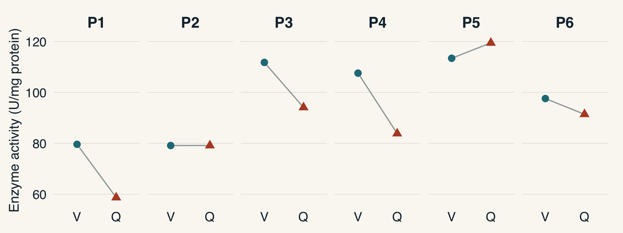

Are most preparations lower with Q?

V = vehicle, Q = compound Q. One dot per tube; one connected pair per preparation. Simulated data.

## How large is each preparation’s change?

Observe · describe to a neighbour · 1 minute

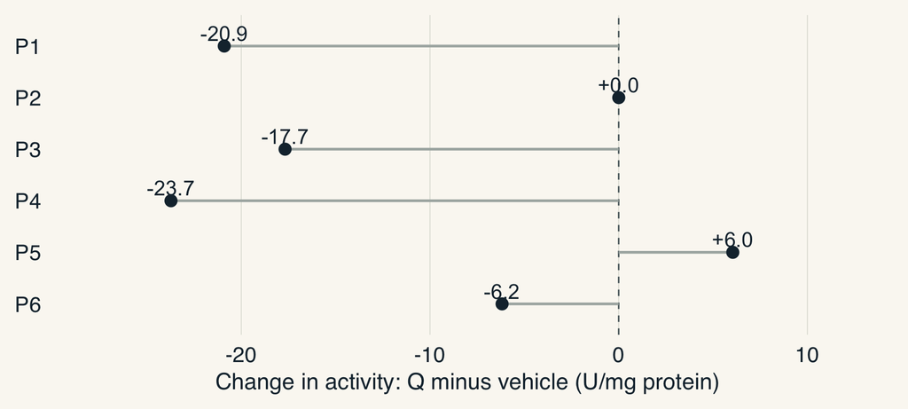

Are the changes similar? Is one unusual? Does one point drive the picture?

Simulated L1 assay. Six independently initiated preparations, each contributing one paired comparison.

## What would one number leave out?

Where?What is a typical change?

How far apart?How much do changes vary?

What pattern?Balanced, clustered, or stretched to one side?

Which observation?Does one preparation stand apart?

Location, spread, shape and unusual observations.

## Which number would stand in for these six?

Choose a value and explain your choice · 1 minute

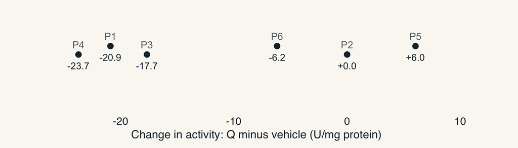

An average of every value? A value in the middle?

Simulated L1 assay. Six independently initiated preparations, each contributing one paired comparison.

## The average and the middle answer different questions

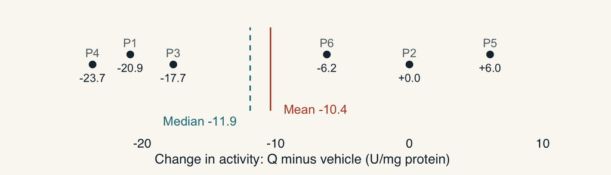

Mean: -10.4 U/mg

Add all six changes, then divide by six.

Median: -11.9 U/mg

Order the changes; average the two middle values.

Simulated L1 assay. Six independently initiated preparations, each contributing one paired comparison.

## What is a quartile?

Sort all values from smallest to largest.  
Cut into four equal pieces.

25%

25%

25%

25%

Q1

Q2 · median

Q3

Q2 is the median — the midpoint we already discussed.

## What if one preparation were extreme?

Predict which summary moves more · then reveal

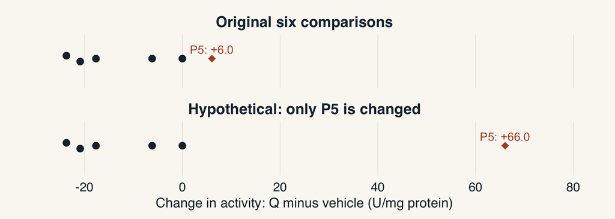

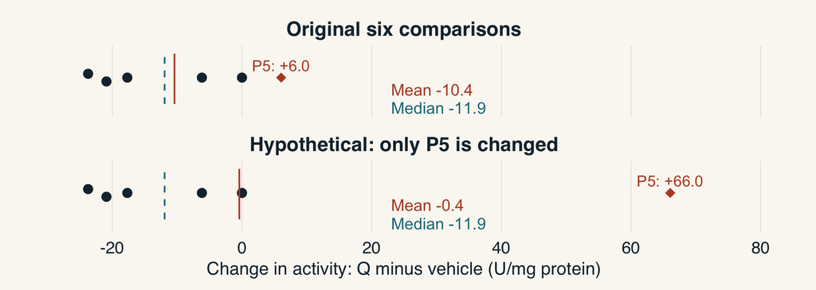

Hypothetical illustration only. The original dataset is unchanged. Each panel contains six paired changes.

## An unusual preparation needs a question

Returning to the original experiment

Why did this preparation  
behave differently?

Check its history

Culture, handling, reagents and assay records.

Keep the result visible

Document any justified exclusion and its reason.

## Do the preparations all tell the same story?

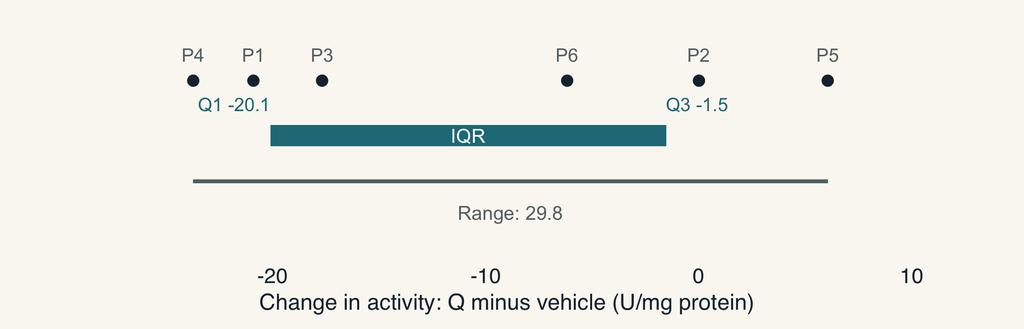

Range: 29.8 U/mg

Largest minus smallest change.

IQR: 18.6 U/mg

Distance from the lower to the upper quartile.

Simulated L1 assay. Six independently initiated preparations, each contributing one paired comparison.

## How far do changes lie from their mean?

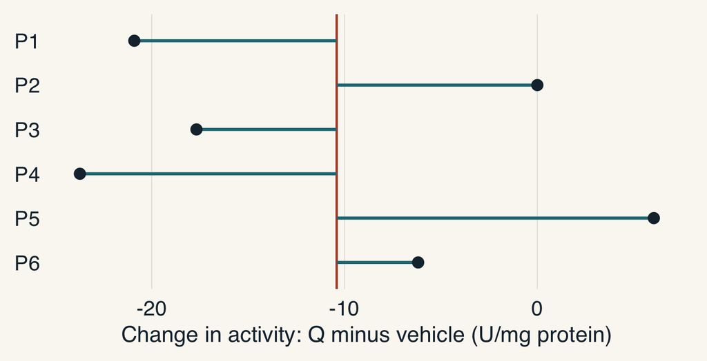

Variance

Summarizes squared distances from the mean.

Standard deviation

The square root puts spread back in the measurement units.

SD = 12.1 U/mg

Simulated L1 assay. Six independently initiated preparations, each contributing one paired comparison.

## Could these have the same mean and SD?

Predict before revealing

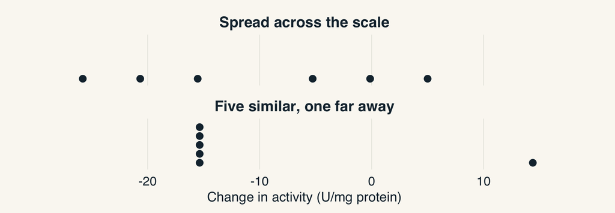

Both: mean -10.4, SD 12.1 U/mg.

Constructed illustrations, not additional experiments. Six values each, scaled to the original data’s mean and SD.

## Which plot preserves the information we need?

The paired values

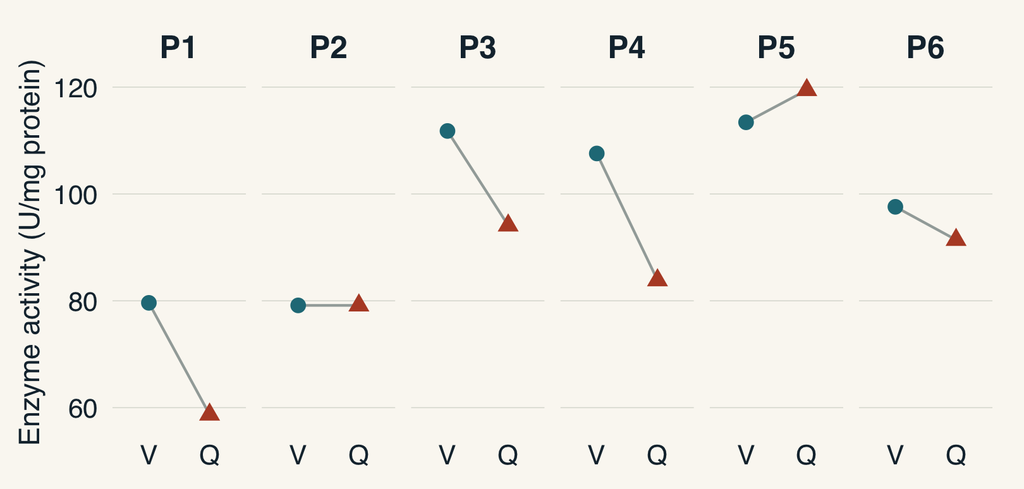

Starting values and within-preparation change.

The six changes

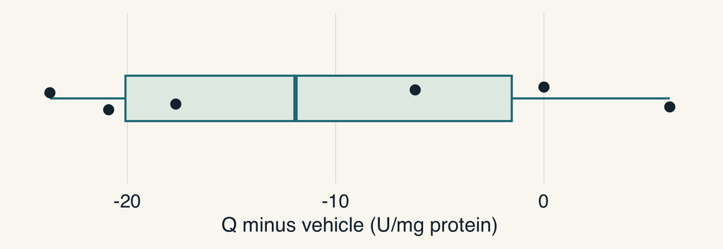

A compact summary, with every change visible.

Same original simulated assay. Left: 12 tube values forming six pairs. Right: six Q-minus-vehicle changes.

## What most papers show

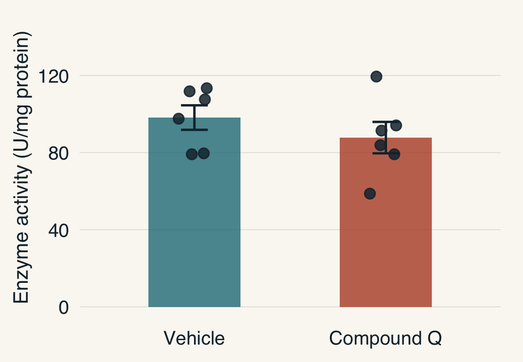

Mean ± SEM. The pairing that gave us six clean comparisons is gone.

Same six L1 preparations. Error bars: ±1 SEM. Jitter shows scatter within each group, not which points came from the same preparation.

## What does n = 6 actually count?

Mean paired change: **-10.4 U/mg**  
SD of the paired changes: **12.1 U/mg**

Six independently initiated  
culture preparations

Each contributes one paired treatment–control comparison.

## How would you describe this result to a colleague?

Write two sentences · 1 minute

Direction and size.  
Variation and any unusual preparation.  
What the six observations count.

Four preparations decreased, one was almost unchanged and one increased.  
The mean paired change was -10.4 U/mg, with SD 12.1 U/mg across six independently initiated L1 preparations.

Describes these simulated observations; does not establish a mechanism or generalize beyond the stated experimental space.

## What can we describe before going further?

DirectionWhich way did the response change?

SizeHow large were the changes?

VariationHow far apart were they?

ConsistencyDid preparations tell the same story?

ExceptionsWas any observation unusual?

ReplicationHow many independent observations generated this picture?

We observed an effect. How precisely do we know its size?

## Six preparations give one estimate

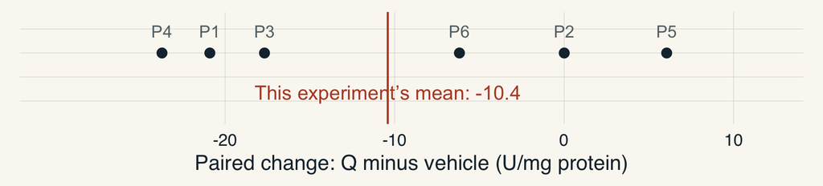

Our estimate from this particular experiment: **−10.4 U/mg**

Simulated L1 assay · Q minus vehicle · six independently initiated preparations.

## If we repeated the experiment, would we get the same answer?

Predict · discuss with a neighbour

Six new preparations.  
The same L1 protocol and paired comparison.

Would the mean be exactly −10.4 again?

Repeat the biological experiment, not the assay on the same lysates.

## New preparations, new mean

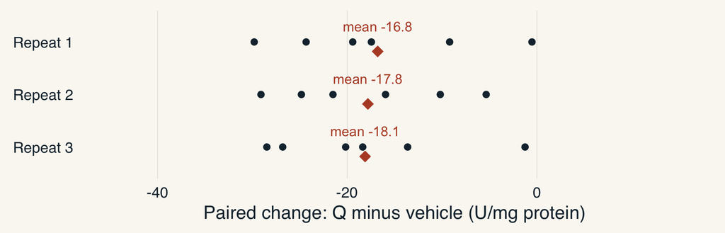

Six dots → one mean in each repetition

In a simulation we choose the truth: here the true mean effect is set to **−14 U/mg**. Our real estimate (−10.4) is one draw from experiments like these.

Dark dots: preparations. Rust diamonds: experiment means.

## What happens when we collect the means?

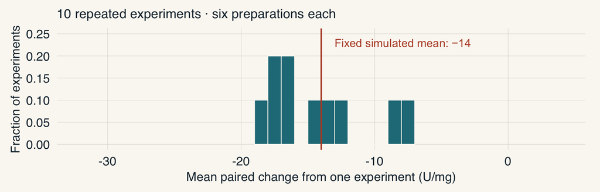

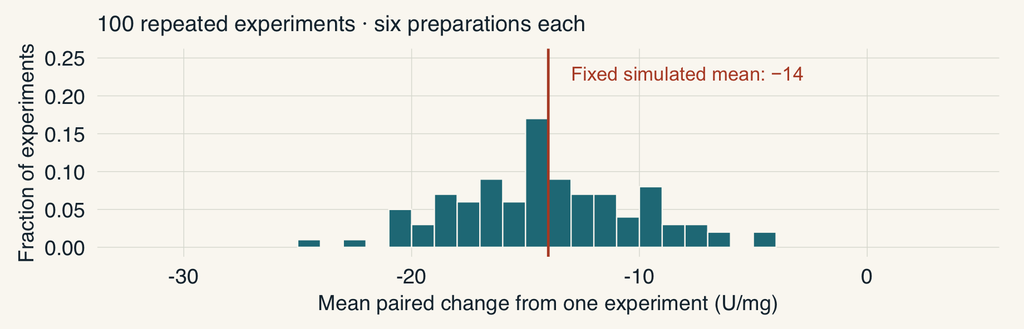

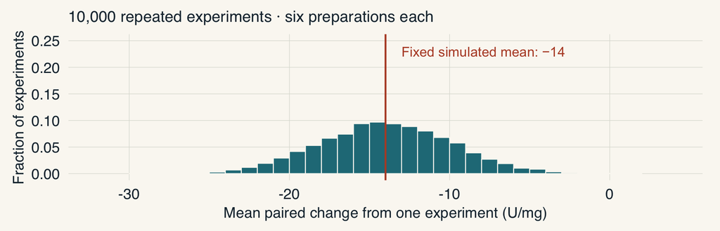

A **sampling distribution**: estimates across repeated experiments

Every entry is one experiment’s mean, not one preparation. Same horizontal scale at every reveal.

## Preparations vary more than their mean does

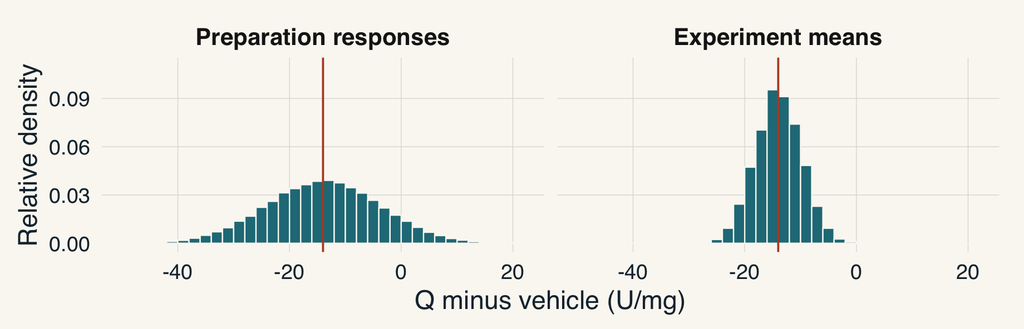

**SD** · spread of preparation responses

**SE** · spread of the estimated mean across repetitions

Both panels use the same simulation model. Each experiment on the right has n = 6.

## How can one experiment estimate that spread?

For independent preparation-level changes:

SE(mean) = SD / √n

Our estimated SE: 12.1 / √6 ≈ **4.96 U/mg**

SD is the sample SD of paired changes. n counts preparation pairs, not technical readings.

## What would make the answer more precise?

Predict before revealing

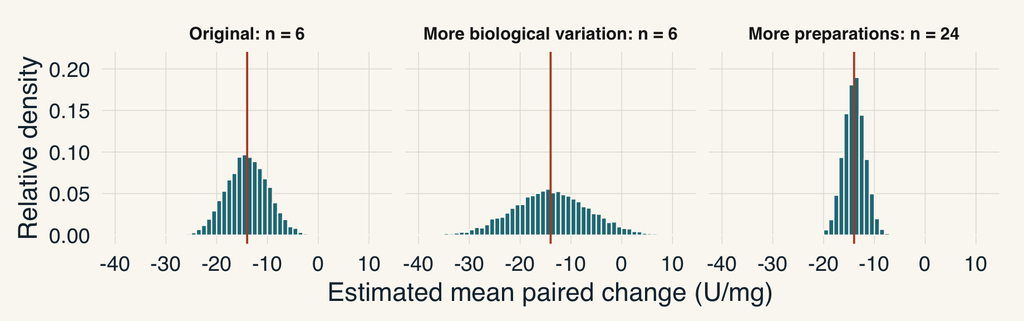

More biological variation → larger SE  
More independent preparations → smaller SE

Simulated true mean −14 U/mg in all three scenarios. All plots show experiment means.

## Can we show a range around our estimate?

Instead of giving only our best estimate, can we show a range of values compatible with its uncertainty?

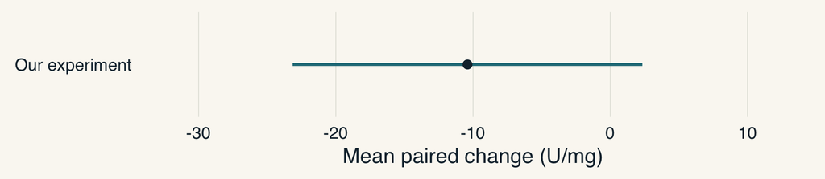

A 95% confidence interval for the **mean paired effect**

Assumes independent, approximately normal paired changes under this L1 protocol.

## Would the intervals keep finding the true mean?

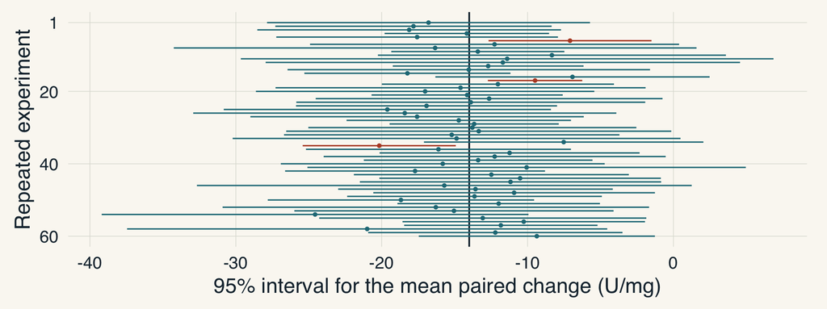

95.3% covered the true mean across 10,000 repetitions

First 60 shown, in order. Vertical line: the simulated true mean, −14. Teal intervals contain it; rust intervals miss it.

## What does our interval tell us?

Our result: −23 to +2 U/mg.

These are the effect sizes the data cannot rule out.

The interval shows compatible values — not a probability that the true effect is inside it.

Wider interval = less precise estimate, not a worse experiment.

## Same estimate. Which answer is more precise?

Predict before the reveal

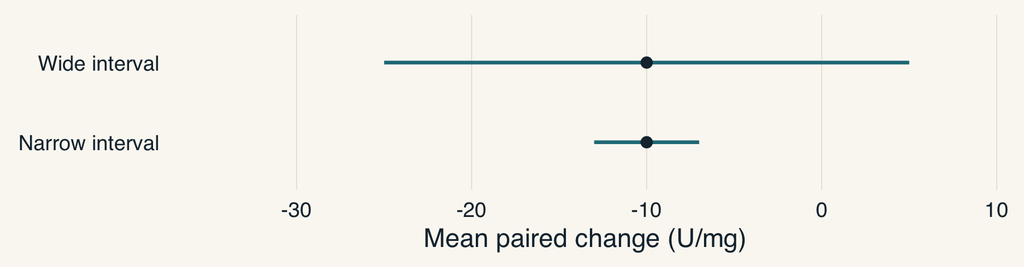

The narrower interval gives a more precise estimate.

Constructed 95% CI illustrations on the same scale, not additional L1 observations.

## Is a large effect always precisely known?

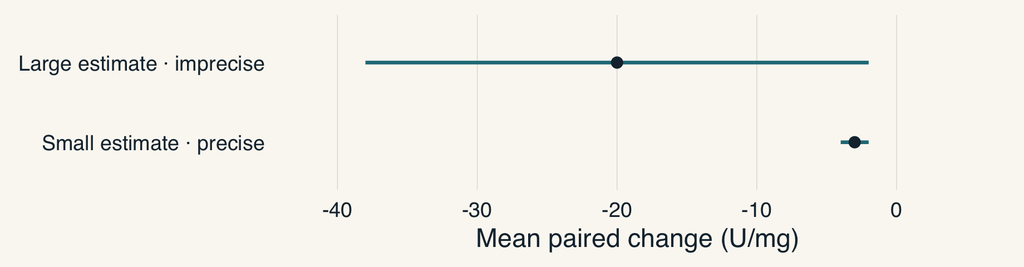

Magnitude: where is the estimate?  
Precision: how wide is its interval?

Constructed 95% CI illustrations · biological importance requires biological judgment.

## What can we now say about compound Q?

Formulate a statement · 1 minute

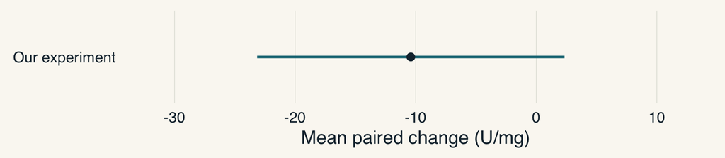

**−10.4 U/mg** · 95% CI **−23.2 to +2.3**

Best estimate? Remaining uncertainty?  
Which effect sizes remain compatible? Narrow enough for our biological question?

Six L1 preparations · Q minus vehicle · conditional on independent, approximately normal paired changes.

## Report the estimate and its precision

### SD — spread of preparations

How much do individual  
preparations vary?

Describes biological variability  
across observations.

### SE or CI — estimate precision

How well does the mean  
characterise the true average?

Describes how precisely  
we know the average effect.

Report what your reader needs: the effect size and how precisely it is known.

## One question to carry forward

Suppose there were actually no average treatment effect. How unusual would our observed estimate be?

## Could this result arise if there were no effect?

Predict before the reveal

We observed a mean paired change of **−10.4 U/mg**.

What would we expect if the true average treatment effect were exactly zero?

Same variability. Six new preparations.  
Same paired experiment. True mean **0**.

Hypothetical L1 model: no average effect, not identical responses in every preparation.

## Zero on average does not mean zero every time

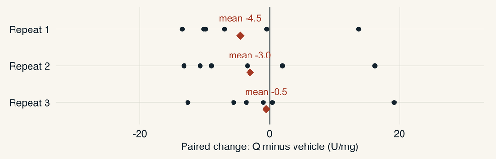

Different sample means, even when the true mean is zero

Dark dots: preparation changes. Rust diamonds: means. Vertical line: fixed true mean 0.

## What would the no-effect model produce?

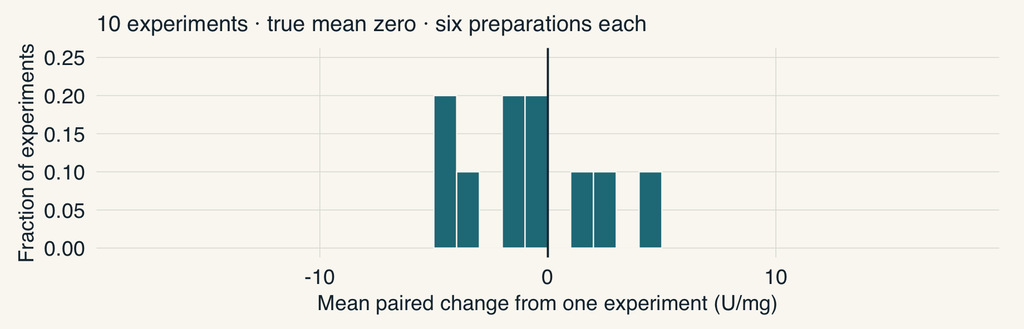

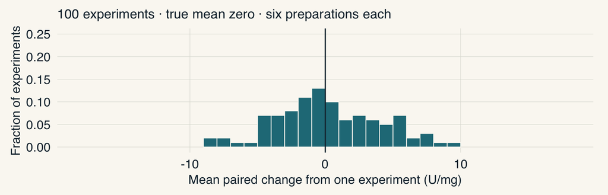

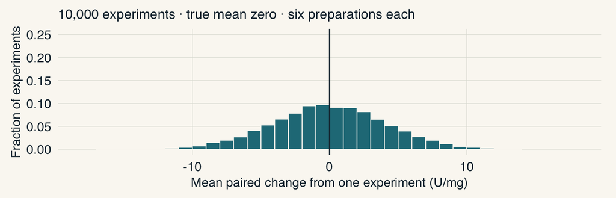

The **null distribution** · H<sub>0</sub>: mean paired effect = 0

One entry = one experiment’s mean. Six new paired changes per experiment.

## Does our observed mean look ordinary here?

Ordinary or unusual? · look before reading on

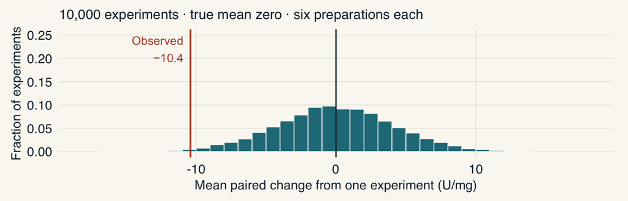

Ordinary or unusual under this no-average-effect model?

Same null simulation and axes. Observed data remain unchanged.

## Is −10.4 equally surprising in every experiment?

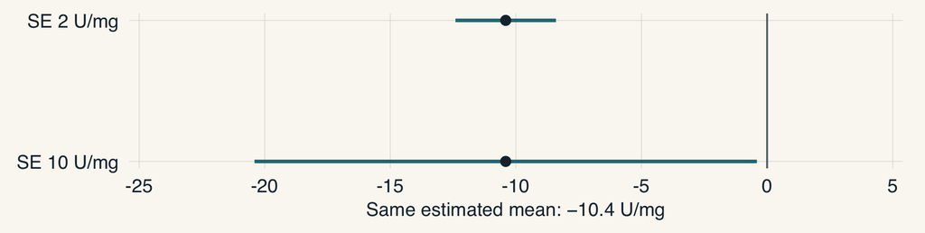

The distance from zero needs a scale.

Constructed comparison. Lines show ±1 estimated SE, not confidence intervals or a recommended generic error-bar display.

## How many standard errors away from zero?

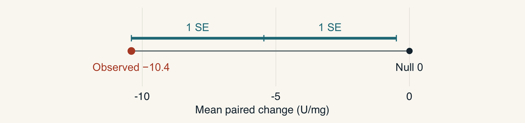

Our mean sits 2.1 SE steps below zero.

This distance, counted in SE steps, is called **t**. Here t = −2.10.

Now we ask: how often would chance alone produce a result at least that far from zero?

## How often would a result be at least this extreme?

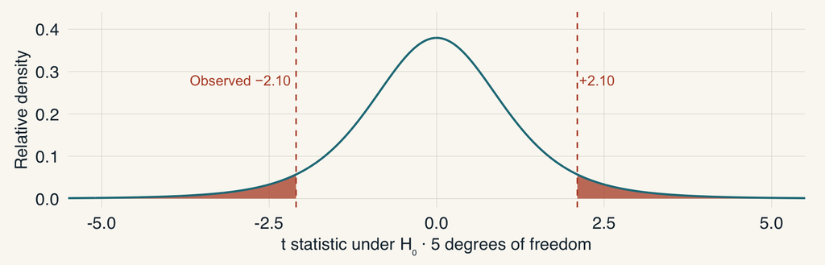

The p-value: if there were no true effect, how often would an experiment land at least as far from zero as ours — 2.1 SE steps, in either direction?

**Two-sided p = 0.090** · both directions count